# Workshop: Inverse Probability of Treatment Weighting (IPTW) in R

Author

Armando Teixeira-Pinto

Published

July 1, 2025

# 1 Quick Background

We’ll simulate a clinical dataset on 500 patients: exposure = drug (binary: 1=yes, 0=no), outcome = recovery (binary: 1=yes, 0=no), confounders = age (continuous), gender (binary), severity (continuous). Confounding: older/male/higher severity less likely to get drug but affect recovery.

**Note**: Run the code in RStudio or your R environment. We’ll use packages like `ipw` for weights, `cobalt` for balance checks, and `survey` for weighted analysis.

# 2 Example: Two-Category Exposure

## 2.1 Install and Load Packages

We need `ipw` for IPTW, `cobalt` for balance diagnostics, `survey` for weighted models, and `ggplot2` for plots.

```r
# Install packages if not already installed
#install.packages(c("ipw", "cobalt", "survey", "ggplot2"))

# Load libraries
library(ipw)
library(cobalt)
library(survey)
library(ggplot2)
library(gtsummary)
```

- **What this does**: Installs/loads tools. `ipw` computes weights; `cobalt` assesses balance; `survey` handles weighted regressions.

## 2.2 Simulate the Clinical Dataset

We’ll create data with confounding: drug less likely for older, male, severe patients; recovery lower for older, severe.

```r
# Set seed for reproducibility
set.seed(456)

# Simulate 500 patients
n <- 500
age <- rnorm(n, mean = 60, sd = 10)  # Age ~ N(60, 10)
gender <- rbinom(n, 1, 0.5)  # Gender: 0=female, 1=male
severity <- rnorm(n, mean = 5, sd = 2)  # Severity score ~ N(5, 2)

# Propensity: lower for older, male, severe
logit_ps <- -.1 - 0.02 * age - 0.5 * gender - 0.1 * severity
ps <- plogis(logit_ps)
drug <- rbinom(n, 1, ps)  # Exposure: drug (1=yes)

# Outcome: recovery higher with drug, lower with age/severity
logit_y <- 2.5 + 1.5 * drug  -0.03 * age  -0.2 * gender  -0.4 * severity
recovery <- rbinom(n, 1, plogis(logit_y))  # Outcome: recovery (1=yes)

# Combine into data frame
data <- data.frame(age, gender, severity, drug, recovery)

# View summary
tbl_summary(data)
```

| **Characteristic** | **N = 500**<sup>1</sup> |
| --- | --- |
| age | 61 (54, 68) |
| gender | 261 (52%) |
| severity | 5.04 (3.81, 6.47) |
| drug | 65 (13%) |
| recovery | 129 (26%) |

<sup>1</sup> Median (Q1, Q3); n (%)

- **What this does**: Generates confounded data. Approximately true ATE: drug increases recovery odds by exp(1.5) ≈ 4.48.
- **Expected output** : Table with summaries

## 2.3 Estimate Propensity Scores

Fit logistic regression for PS: P(drug=1 | age, gender, severity).

```r
# Fit PS model
ps_model <- glm(drug ~ age + gender + severity,
                family = binomial,
                data = data)
data$ps <- predict(ps_model, type = "response") #PS

# Summary of PS
summary(data$ps)
```

```
   Min. 1st Qu.  Median    Mean 3rd Qu.    Max.
 0.0194  0.0821  0.1185  0.1300  0.1646  0.4005
```

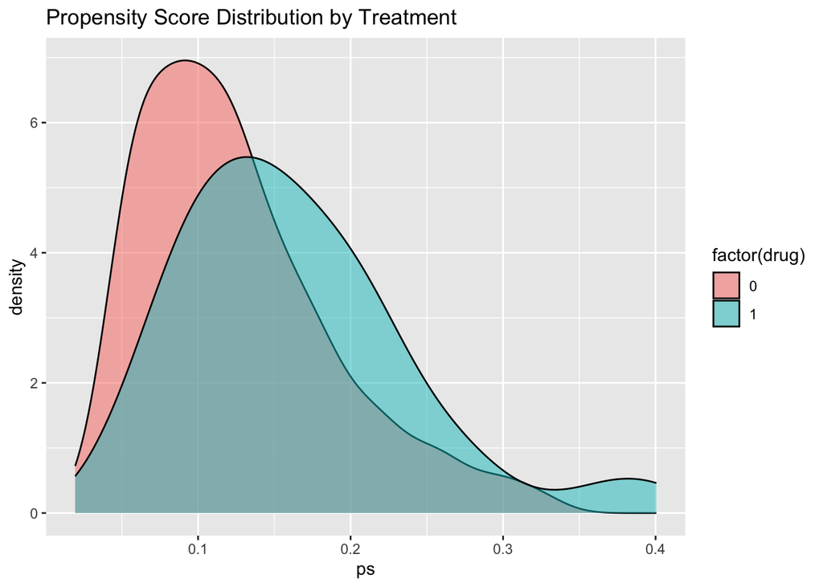

```r
ggplot(data, aes(x = ps, fill = factor(drug))) +
    geom_density(alpha = 0.5) +
  labs(title = "Propensity Score Distribution by Treatment")
```

## 2.4 Compute IPTW Weights

Use stabilized weights for stability.

```r
# Marginal P(drug=1)
p_drug <- mean(data$drug)

# Stabilized weights
data$sw <- ifelse(data$drug == 1,
                  p_drug / data$ps,
                  (1 - p_drug) / (1 - data$ps))

# Summary of weights
summary(data$sw)
```

```
   Min. 1st Qu.  Median    Mean 3rd Qu.    Max.
 0.3246  0.9347  0.9783  0.9987  1.0372  2.8843
```

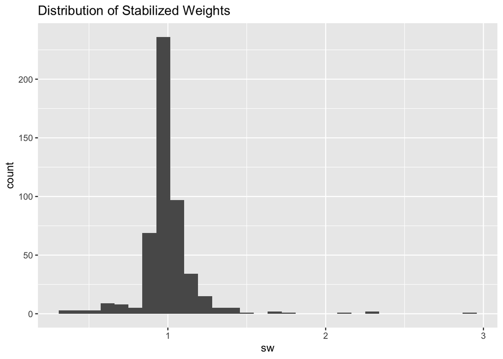

```r
ggplot(data, aes(x = sw)) +
    geom_histogram() +
    labs(title = "Distribution of Stabilized Weights")
```

## 2.5 Check Balance

Assess confounder balance pre/post weighting using standardized mean differences (SMD <0.1 ideal).

```r
# Balance check with cobalt
bal <- bal.tab(drug ~ age + gender + severity, data = data, weights = data$sw,
               method = "weighting",
               estimand = "ATE")
print(bal)
```

```
Balance Measures
            Type Diff.Adj
age      Contin.  -0.0157
gender    Binary  -0.0256
severity Contin.   0.0005

Effective sample sizes
           Control Treated
Unadjusted  435.     65.
Adjusted    432.36   51.82
```

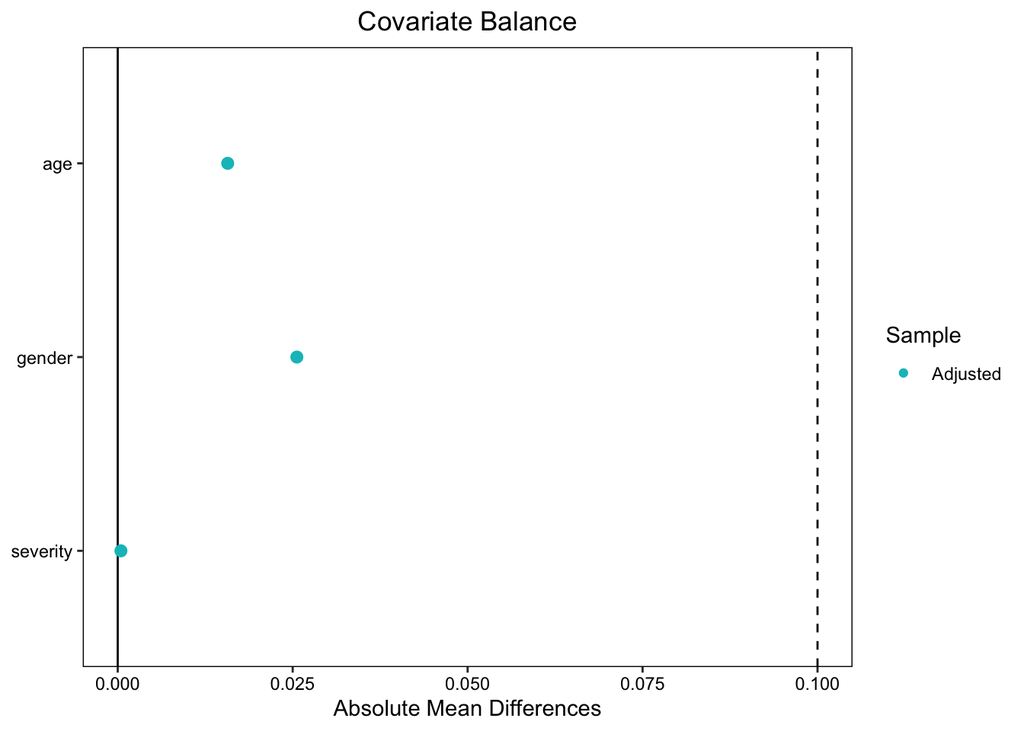

```r
# Love plot
love.plot(bal, threshold = 0.1, abs = TRUE)
```

## 2.6 Estimate Treatment Effect with Weighted Analysis

Use weighted logistic regression via `survey` for ATE on odds ratio scale (or risk difference with linear).

```r
# Create survey design
svy_design <- svydesign(ids = ~1,
                        weights = ~sw,
                        data = data)

# Weighted GLM for OR
fit_weighted <- svyglm(recovery ~ drug,
                       design = svy_design,
                       family = binomial)
tbl_regression(fit_weighted, exponentiate = T)
```

| **Characteristic** | **OR** | **95% CI** | **p-value** |
| --- | --- | --- | --- |
| drug | 4.16 | 2.29, 7.58 | <0.001 |

Abbreviations: CI = Confidence Interval, OR = Odds Ratio

- **What this does**: Estimates ATE.
- **Expected output**: OR ≈ 4.2 (95% CI 2.3-7.6 ), close to true 4.48

## 2.7 Compare to Unweighted Analysis (For Illustration)

Naive model ignores confounding.

```r
# Unweighted GLM
fit_unweighted <- glm(recovery ~ drug,
                      family = binomial,
                      data = data)
tbl_regression(fit_unweighted,
               exponentiate = T)
```

| **Characteristic** | **OR** | **95% CI** | **p-value** |
| --- | --- | --- | --- |
| drug | 5.32 | 3.10, 9.25 | <0.001 |

Abbreviations: CI = Confidence Interval, OR = Odds Ratio

- **Expected**: Biased OR due to confounding.

# 3 More Complex Example: Three-Category Exposure

Now, extend to multi-level exposure: drug_level (0=none, 1=low, 2=high). Use multinomial PS.

## 3.1 Simulate Data with Three-Level Exposure

```r
# Set seed
set.seed(789)

# Confounders
age <- rnorm(n, mean = 60, sd = 10)
gender <- rbinom(n, 1, 0.5)
severity <- rnorm(n, mean = 5, sd = 2)

# Multinomial logits for PS (ref=0)
logit1 <- -1 + -0.01 * age -0.3 * gender -0.05 * severity  # For level 1
logit2 <- 1.5 + -0.03 * age -0.7 * gender -0.15 * severity  # For level 2
prob0 <- 1 / (1 + exp(logit1) + exp(logit2))
prob1 <- exp(logit1) * prob0
prob2 <- exp(logit2) * prob0

# Sample drug_level
drug_level <- sapply(1:n, function(i) sample(0:2, 1, prob = c(prob0[i], prob1[i], prob2[i])))

# Outcome: dose-response
logit_y <- 1 + 2.0 * (drug_level == 1) + 2.0 * (drug_level == 2) - 0.03 * age - 0.2 * gender - 0.4 * severity
recovery <- rbinom(n, 1, plogis(logit_y))

# Data frame
data_multi <- data.frame(age, gender, severity,
                         drug_level = factor(drug_level),
                         recovery)

tbl_summary(data_multi)
```

| **Characteristic** | **N = 500**<sup>1</sup> |
| --- | --- |
| age | 60 (53, 67) |
| gender | 252 (50%) |
| severity | 4.98 (3.54, 6.15) |
| drug_level |  |
| 0 | 351 (70%) |
| 1 | 45 (9.0%) |
| 2 | 104 (21%) |
| recovery | 73 (15%) |

<sup>1</sup> Median (Q1, Q3); n (%)

## 3.2 Estimate Generalized Propensity Scores

Use multinomial logistic via `nnet`.

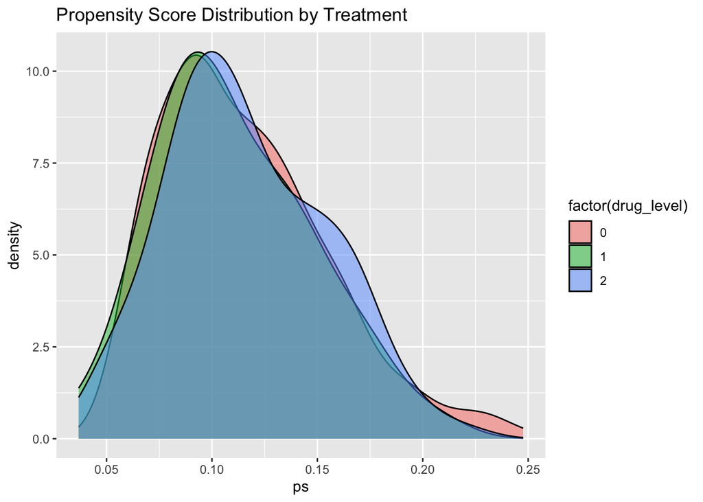

```r
library(nnet)
ps_model_multi <- multinom(drug_level ~ age + gender + severity,
                           data = data_multi)
# Matrix of PS for each level
ps_multi <- predict(ps_model_multi, type = "probs")

# Observed PS
data_multi$ps_obs <- sapply(1:n,
                            function(i) ps_multi[i, as.character(data_multi$drug_level[i])])

ggplot(data_multi, aes(x = ps, fill = factor(drug_level))) +
    geom_density(alpha = 0.5) +
  labs(title = "Propensity Score Distribution by Treatment")
```

## 3.3 Compute Generalized IPTW Weights

Stabilized: SW = P(A=a) / PS(A=a | confounders)

```r
p_drug_level <- prop.table(table(data_multi$drug_level))  # Marginal prob

data_multi$sw <- ifelse(data_multi$drug_level == 0,
                        p_drug_level[1]/data_multi$ps_obs,
                        ifelse(data_multi$drug_level == 1,
                               p_drug_level[2]/data_multi$ps_obs,
                                p_drug_level[3]/data_multi$ps_obs))

summary(data_multi$sw)
```

```
   Min. 1st Qu.  Median    Mean 3rd Qu.    Max.
 0.3431  0.8302  0.9164  1.0011  1.1061  4.2041
```

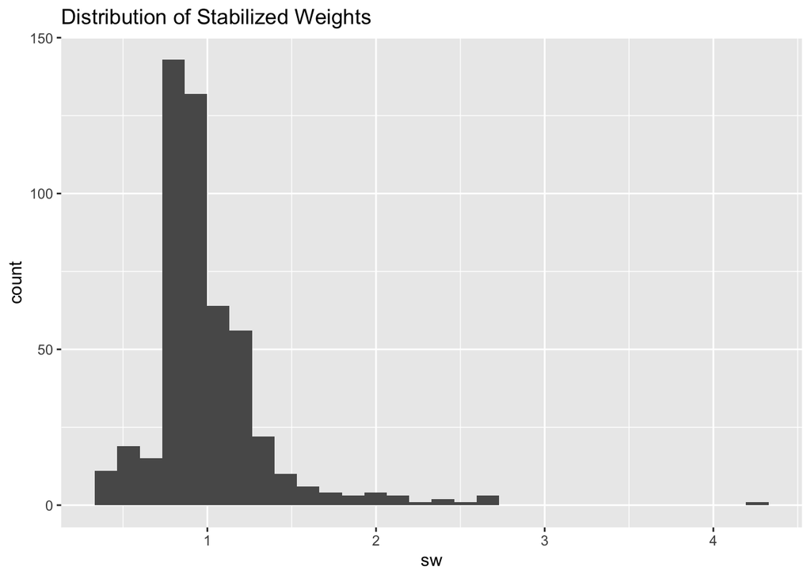

```r
ggplot(data_multi, aes(x = sw)) +
    geom_histogram() +
    labs(title = "Distribution of Stabilized Weights")
```

## 3.4 Check Balance

For multi-level, compare each pair or use generalized balance.

```r
# Balance check with cobalt
bal_multi <- bal.tab(drug_level ~ age + gender + severity,
                     data = data_multi,
                     weights = data_multi$sw,
                     method = "weighting",
                     estimand = "ATE",
                     which.treat = .all)
print(bal_multi)
```

```
Balance by treatment pair

 - - - 0 (0) vs. 1 (1) - - -
Balance Measures
            Type Diff.Adj
age      Contin.  -0.0102
gender    Binary  -0.0006
severity Contin.  -0.0065

Effective sample sizes
                0     1
Unadjusted 351.   45.
Adjusted   336.92 43.69

 - - - 0 (0) vs. 2 (1) - - -
Balance Measures
            Type Diff.Adj
age      Contin.  -0.0686
gender    Binary   0.0112
severity Contin.   0.0368

Effective sample sizes
                0      2
Unadjusted 351.   104.
Adjusted   336.92  72.29

 - - - 1 (0) vs. 2 (1) - - -
Balance Measures
            Type Diff.Adj
age      Contin.  -0.0584
gender    Binary   0.0117
severity Contin.   0.0433

Effective sample sizes
               1      2
Unadjusted 45.   104.
Adjusted   43.69  72.29
 - - - - - - - - - - - - - - - -
```

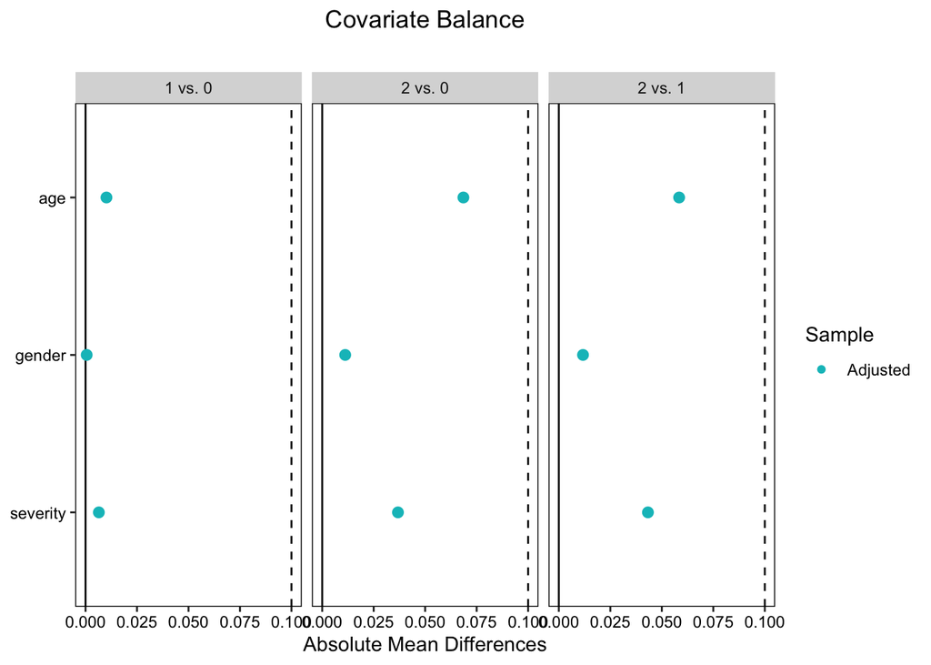

```r
# Love plot
love.plot(bal_multi, threshold = 0.1, abs = TRUE)
```

- **Expected**: Weighted SMD <0.1 across comparisons.

## 3.5 Weighted Analysis

Weighted GLM with factor exposure.

```r
svy_design_multi <- svydesign(ids = ~1,
                              weights = ~sw,
                              data = data_multi)

fit_weighted_multi <- svyglm(recovery ~ drug_level,
                             design = svy_design_multi,
                             family = binomial)

tbl_regression(fit_weighted_multi, exponentiate = T)
```

| **Characteristic** | **OR** | **95% CI** | **p-value** |
| --- | --- | --- | --- |
| drug_level |  |  |  |
| 0 | — | — |  |
| 1 | 5.21 | 2.33, 11.7 | <0.001 |
| 2 | 7.09 | 3.64, 13.8 | <0.001 |

Abbreviations: CI = Confidence Interval, OR = Odds Ratio

# 4 Workshop Exercises

1. Trim weights at 1st/99th percentile—how does effect change?
2. Add interactions in PS model.
3. Use `WeightIt` package for alternative weighting.
4. Apply to real data (e.g., from `twang` package examples).

This covers IPTW for binary and multi-level exposures! If questions, let me know.